# Mall Customer Segmentation

# Subject: Cluster Analysis

# Students Names:

- Hotheifa Mohammad Al-3Assi 2021057039
- Omar khaled Smadi 2021057241
- Hotheifa Mahmoud Nzazleh 2021057204
- Mohammad Majed Nassireh 2019057195

# Supervisor Name: Dr.Aymen Al-Rawashdeh

# Submission Date: 6-1-2026

# Cluster analysis:

is a data analysis technique that groups similar data points into “clusters,” where items within a cluster are more alike to each other than to items in other clusters, helping discover natural groupings in data without prior labels (unsupervised learning). It’s used in fields like marketing (customer segmentation) or healthcare (patient grouping) to find patterns, understand relationships, and simplify complex data sets by highlighting similarities and differences.

# How it works:

- Finds natural groups: It identifies inherent structures within data, like grouping customers by buying habits or patients by symptoms.
- Measures similarity: It uses criteria like distance, density, or statistical distributions to determine how alike data points are.
- Unsupervised learning: Since it doesn’t use predefined categories, it’s great for exploring data and discovering new insights.

# Key characteristics:

- High intra-cluster similarity: Objects within the same cluster are very similar.
- Low inter-cluster similarity: Objects in different clusters are dissimilar.

# Common methods:

- K-Means Clustering: Divides data into a pre-specified number (k) of clusters.
- Hierarchical Clustering: Creates a tree-like hierarchy of clusters, useful for seeing relationships at different levels.

# About This Data:

- This data set contains customer data that can be used for segmentation analysis. It includes demographic and behavioral information about customers, which can help in identifying distinct segments within the customer base. This can be particularly useful for targeted marketing strategies, improving customer satisfaction, and increasing sales.

# we will use a cluster analysis for this data, by applying k-means methods:

- K-Means Clustering Method:
  - K-means clustering (Mac Queen, 1967) is the most commonly used unsupervised machine learning algorithm for partitioning a given data set into a set of k clusters.
  - k represents the number of clusters pre-specified by the analyst
  - It classifies such that objects within the same cluster are as similar as possible (i.e., high intra-class similarity), whereas objects from different clusters are as dissimilar as possible.

# The Data View:

Mall Customer Segmentation

| id | age | Gender | Income | Spending Score | Membership years | Purchase frequency | Preferred category | Last purchase amount |
| --- | --- | --- | --- | --- | --- | --- | --- | --- |
| 1 | 38 | Female | 99342 | 90 | 3 | 24 | Groceries | 113.53 |
| 2 | 21 | Female | 78852 | 60 | 2 | 42 | Sports | 41.93 |
| 3 | 60 | Female | 126573 | 30 | 2 | 28 | Clothing | 424.36 |
| 4 | 40 | Other | 47099 | 74 | 9 | 5 | Home & Garden | 991.93 |
| 5 | 65 | Female | 140621 | 21 | 3 | 25 | Electronics | 347.08 |
| 6 | 31 | Other | 57305 | 24 | 3 | 30 | Home & Garden | 86.85 |
| 7 | 19 | Other | 54319 | 68 | 5 | 43 | Clothing | 191.72 |
| 8 | 43 | Male | 108115 | 94 | 9 | 27 | Groceries | 734.56 |
| 9 | 53 | Male | 34424 | 29 | 6 | 7 | Sports | 951.71 |
| 10 | 55 | Female | 45839 | 55 | 7 | 2 | Electronics | 821.18 |

Mall Customer Segmentation

| id | age | Gender | Income | Spending Score | Membership years | Purchase frequency | Preferred category | Last purchase amount |
| --- | --- | --- | --- | --- | --- | --- | --- | --- |
| 990 | 31 | Other | 45695 | 36 | 2 | 31 | Electronics | 864.67 |
| 991 | 21 | Other | 80264 | 41 | 4 | 26 | Sports | 458.93 |
| 992 | 53 | Other | 83578 | 97 | 5 | 50 | Sports | 917.08 |
| 993 | 22 | Female | 125479 | 57 | 8 | 27 | Home & Garden | 139.75 |
| 994 | 29 | Female | 64799 | 42 | 5 | 19 | Electronics | 967.26 |
| 995 | 60 | Male | 71923 | 25 | 2 | 40 | Clothing | 986.97 |
| 996 | 57 | Male | 112170 | 57 | 6 | 1 | Clothing | 313.64 |
| 997 | 23 | Other | 65337 | 76 | 10 | 23 | Groceries | 632.83 |
| 998 | 23 | Male | 113097 | 40 | 5 | 42 | Sports | 75.09 |
| 999 | 22 | Female | 113695 | 63 | 7 | 44 | Electronics | 505.16 |
| 1000 | 36 | Female | 90420 | 7 | 2 | 31 | Groceries | 669.26 |

# Variable type & Summary:

- Dimension for Data:

Dimensions of the Dataset

| Dimension | Value |
| --- | --- |
| Number of Rows | 1000 |
| Number of Columns | 9 |

The table shows that the number of data (rows) = 1000, and the number of variables (columns) = 9 We excluded the first column (Id) because it only represents the person*.

- Variable Type:

Structure of the Dataset

| Variable | Type | Example |
| --- | --- | --- |
| id | integer | 1, 2, 3, 4 |
| age | integer | 38, 21, 60, 40 |
| gender | character | Female, Female, Female, Other |
| income | integer | 99342, 78852, 126573, 47099 |
| spending_score | integer | 90, 60, 30, 74 |
| membership_years | integer | 3, 2, 2, 9 |
| purchase_frequency | integer | 24, 42, 28, 5 |
| preferred_category | character | Groceries, Sports, Clothing, Home & Garden |
| last_purchase_amount | numeric | 113.53, 41.93, 424.36, 991.93 |

- Summary of Quanitative Variable:

Summary of Quanitative Variable

|  | Age | Income | Spending Score | Membership Years | Purchase frequency | last Purchase Amount |
| --- | --- | --- | --- | --- | --- | --- |
| Min. | 18.000 | 30004.00 | 1.000 | 1.000 | 1.000 | 10.4000 |
| 1st Qu. | 30.000 | 57911.75 | 26.000 | 3.000 | 15.000 | 218.7625 |
| Median | 45.000 | 87845.50 | 50.000 | 5.000 | 27.000 | 491.5950 |
| Mean | 43.783 | 88500.80 | 50.685 | 5.469 | 26.596 | 492.3487 |
| 3rd Qu. | 57.000 | 116110.25 | 76.000 | 8.000 | 39.000 | 747.1700 |
| Max. | 69.000 | 149973.00 | 100.000 | 10.000 | 50.000 | 999.7400 |

- Summary For Qualitative Variable:

Summary of Gender

| Gender | Frequency | Percentage |
| --- | --- | --- |
| Female | 316 | 31.6 |
| Male | 357 | 35.7 |
| Other | 327 | 32.7 |

Summary of Preferred Category

| preferred_category | Frequency | Percentage |
| --- | --- | --- |
| Clothing | 170 | 17.0 |
| Electronics | 215 | 21.5 |
| Groceries | 199 | 19.9 |
| Home & Garden | 206 | 20.6 |
| Sports | 210 | 21.0 |

# Plot for the Quntitative Variable:

- Boxplots:

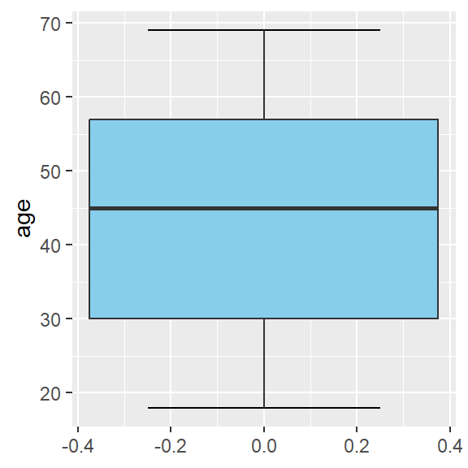

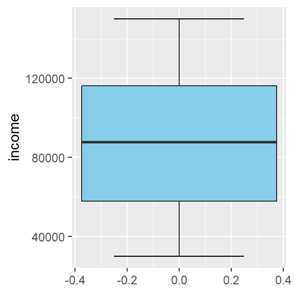

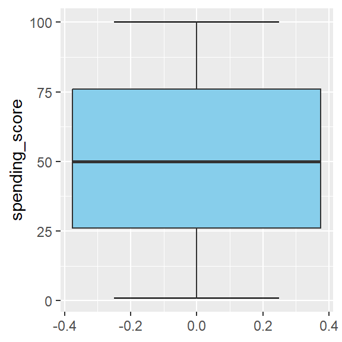

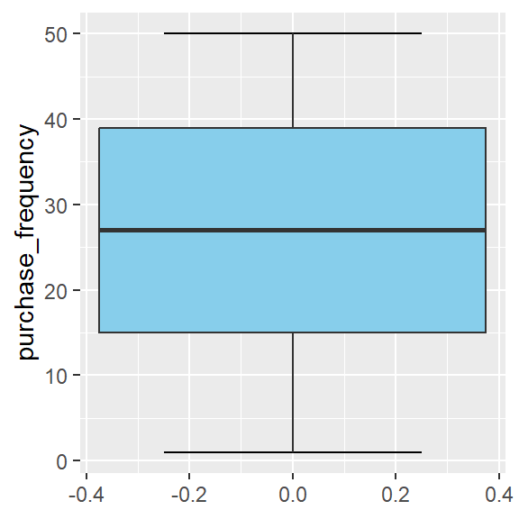

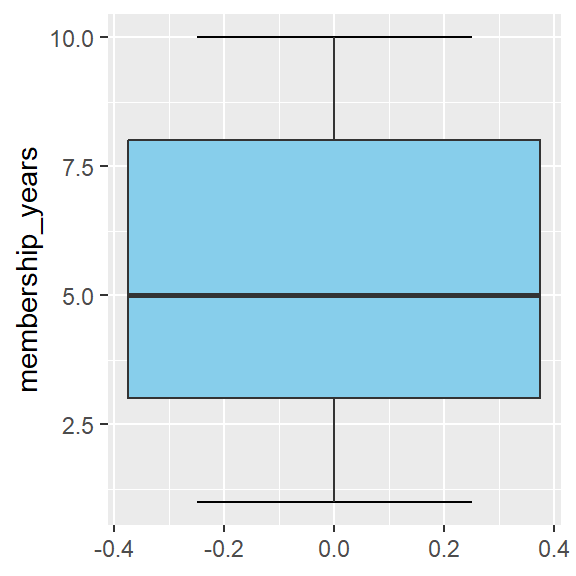

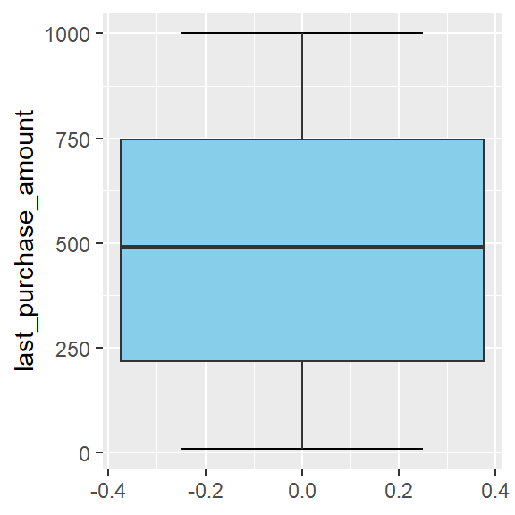

- Histogram plots:

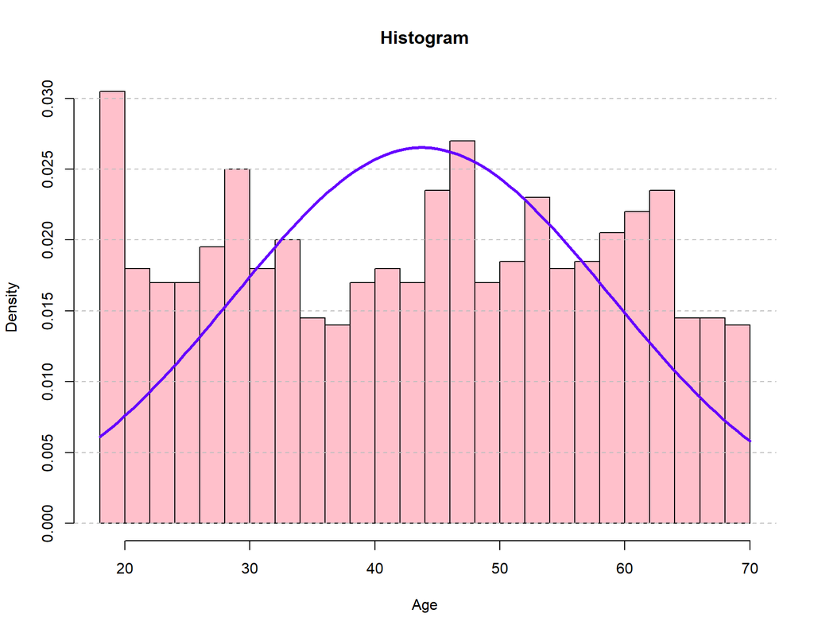

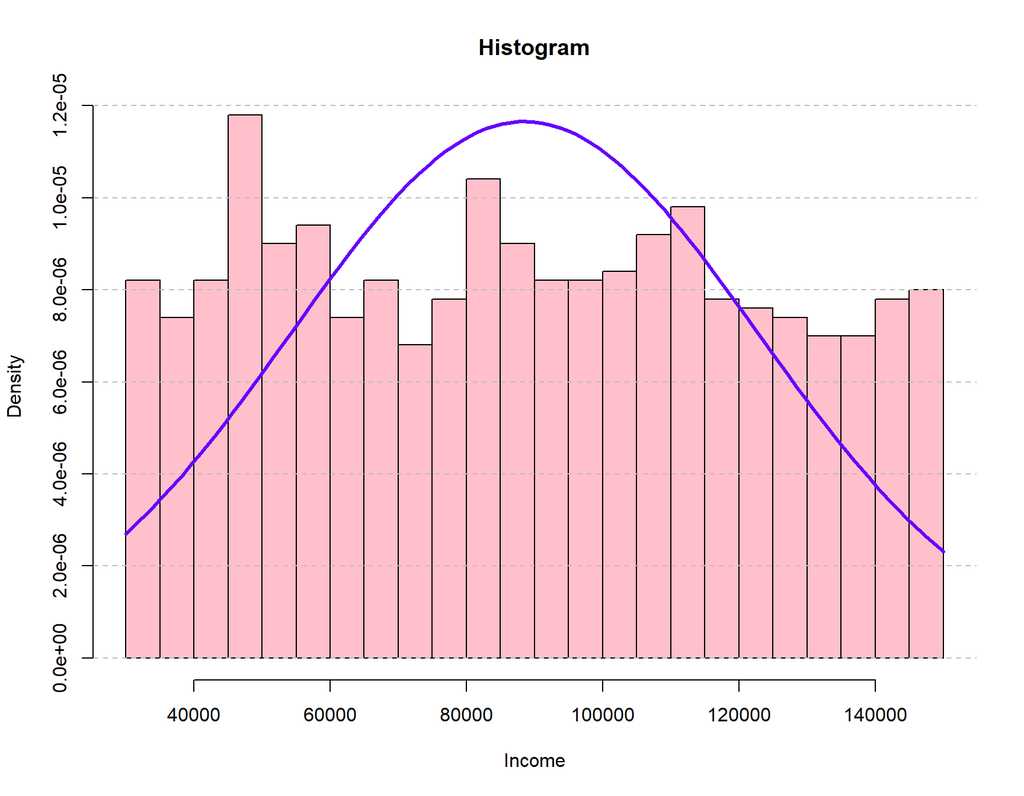

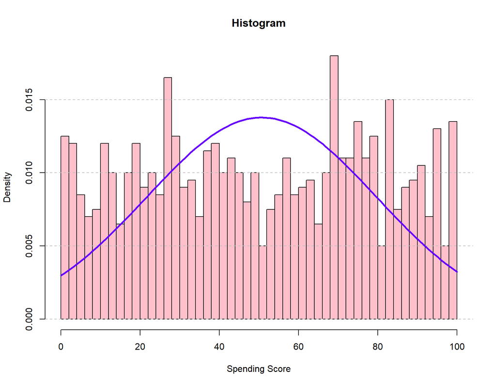

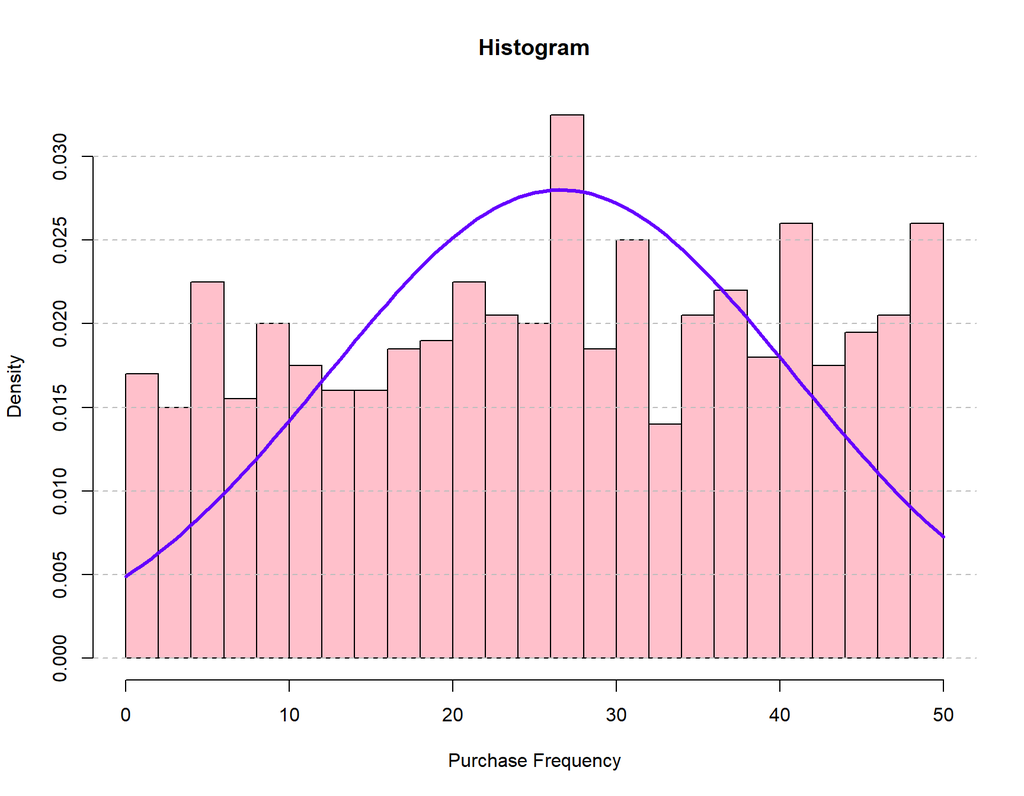

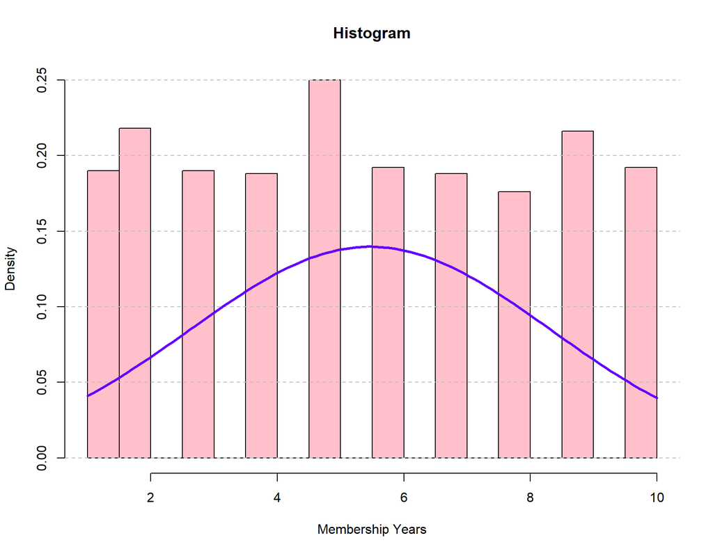

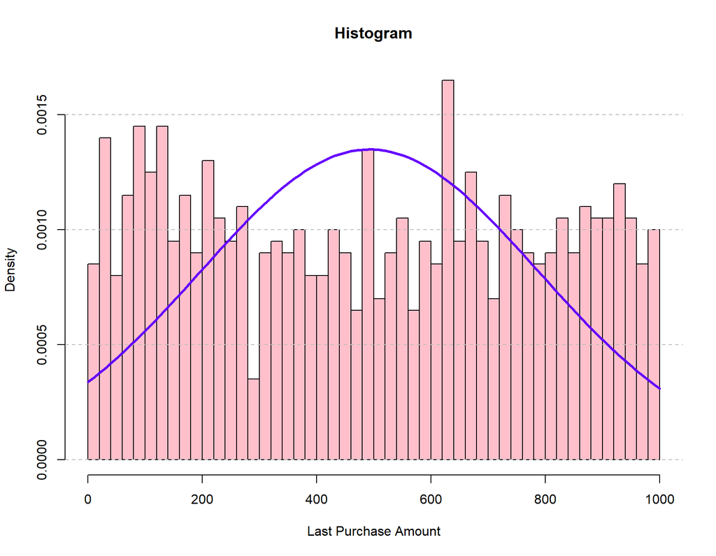

# Plot for Qualitative Variable:

- Barchart:

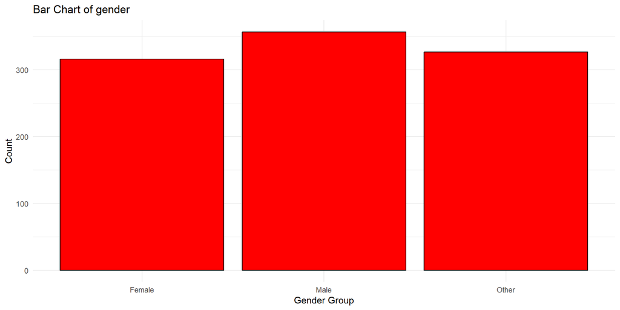

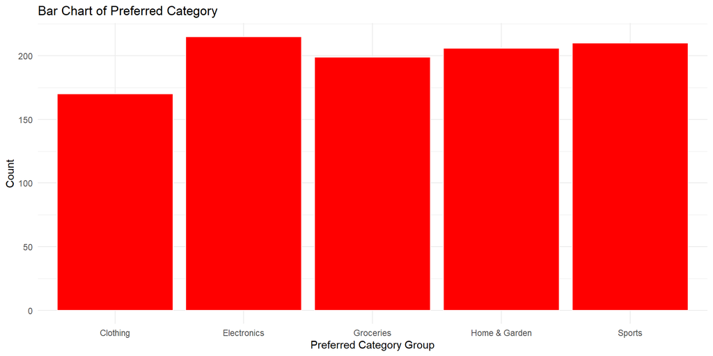

# Applying K-Means Clustering Method:

Mall Customer Segmentation

| id | age | Income | Spending Score | Membership years | Purchase frequency | Last purchase amount |
| --- | --- | --- | --- | --- | --- | --- |
| 1 | 38 | 99342 | 90 | 3 | 24 | 113.53 |
| 2 | 21 | 78852 | 60 | 2 | 42 | 41.93 |
| 3 | 60 | 126573 | 30 | 2 | 28 | 424.36 |
| 4 | 40 | 47099 | 74 | 9 | 5 | 991.93 |
| 5 | 65 | 140621 | 21 | 3 | 25 | 347.08 |
| 6 | 31 | 57305 | 24 | 3 | 30 | 86.85 |
| 7 | 19 | 54319 | 68 | 5 | 43 | 191.72 |
| 8 | 43 | 108115 | 94 | 9 | 27 | 734.56 |
| 9 | 53 | 34424 | 29 | 6 | 7 | 951.71 |
| 10 | 55 | 45839 | 55 | 7 | 2 | 821.18 |

Mall Customer Segmentation

| id | age | Income | Spending Score | Membership years | Purchase frequency | Last purchase amount |
| --- | --- | --- | --- | --- | --- | --- |
| 990 | 31 | 45695 | 36 | 2 | 31 | 864.67 |
| 991 | 21 | 80264 | 41 | 4 | 26 | 458.93 |
| 992 | 53 | 83578 | 97 | 5 | 50 | 917.08 |
| 993 | 22 | 125479 | 57 | 8 | 27 | 139.75 |
| 994 | 29 | 64799 | 42 | 5 | 19 | 967.26 |
| 995 | 60 | 71923 | 25 | 2 | 40 | 986.97 |
| 996 | 57 | 112170 | 57 | 6 | 1 | 313.64 |
| 997 | 23 | 65337 | 76 | 10 | 23 | 632.83 |
| 998 | 23 | 113097 | 40 | 5 | 42 | 75.09 |
| 999 | 22 | 113695 | 63 | 7 | 44 | 505.16 |
| 1000 | 36 | 90420 | 7 | 2 | 31 | 669.26 |

- Dimension for Data After selecting Quantitative variable :

Dimensions of the Dataset

| Dimension | Value |
| --- | --- |
| Number of Rows | 1000 |
| Number of Columns | 6 |

# Scale The Data:

- Now scaling The Data to ensure that all variables are measured in the same unit, resulting in a fair division, and to prevent any single variable from having a greater impact on the division than others.
- First Ten rows After scaling data :

Scale Mall Customer Segmentation Data

| age | Income | Spending Score | Membership years | Purchase frequency | Last purchase amount |
| --- | --- | --- | --- | --- | --- |
| -0.3844514 | 0.3167092 | 1.3577884 | -0.8645775 | -0.1822566 | -1.2808995 |
| -1.5146042 | -0.2818750 | 0.3217041 | -1.2147507 | 1.0814641 | -1.5230006 |
| 1.0780993 | 1.1122215 | -0.7143801 | -1.2147507 | 0.0985702 | -0.2298901 |
| -0.2514922 | -1.2094907 | 0.8052101 | 1.2364614 | -1.5161840 | 1.6892343 |
| 1.4104972 | 1.5226125 | -1.0252053 | -0.8645775 | -0.1120499 | -0.4911969 |
| -0.8498085 | -0.9113379 | -0.9215969 | -0.8645775 | 0.2389836 | -1.3711126 |
| -1.6475634 | -0.9985694 | 0.5979933 | -0.1642312 | 1.1516708 | -1.0165157 |
| -0.0520535 | 0.5729991 | 1.4959329 | 1.2364614 | 0.0283635 | 0.8189891 |
| 0.6127423 | -1.5797716 | -0.7489162 | 0.1859419 | -1.3757706 | 1.5532384 |
| 0.7457014 | -1.2462997 | 0.1490234 | 0.5361151 | -1.7268041 | 1.1118773 |

Scale Mall Customer Segmentation Data

| age | Income | Spending Score | Membership years | Purchase frequency | Last purchase amount |
| --- | --- | --- | --- | --- | --- |
| -0.8498085 | -1.2505064 | -0.5071632 | -1.2147507 | 0.3091903 | 1.2589301 |
| -1.5146042 | -0.2406256 | -0.3344825 | -0.5144044 | -0.0418432 | -0.1129985 |
| 0.6127423 | -0.1438121 | 1.5995413 | -0.1642312 | 1.6431178 | 1.4361440 |
| -1.4481247 | 1.0802620 | 0.2180957 | 0.8862882 | 0.0283635 | -1.1922418 |
| -0.9827676 | -0.6924121 | -0.2999464 | -0.1642312 | -0.5332901 | 1.6058176 |
| 1.0780993 | -0.4842953 | -0.8870608 | -1.2147507 | 0.9410507 | 1.6724630 |
| 0.8786606 | 0.6914597 | 0.2180957 | 0.1859419 | -1.7970109 | -0.6042676 |
| -1.3816451 | -0.6766952 | 0.8742824 | 1.5866346 | -0.2524633 | 0.4750095 |
| -1.3816451 | 0.7185406 | -0.3690187 | -0.1642312 | 1.0814641 | -1.4108767 |
| -1.4481247 | 0.7360103 | 0.4253126 | 0.5361151 | 1.2218775 | 0.0433189 |
| -0.5174106 | 0.0560665 | -1.5087113 | -1.2147507 | 0.3091903 | 0.5981903 |

# Plot the scale data:

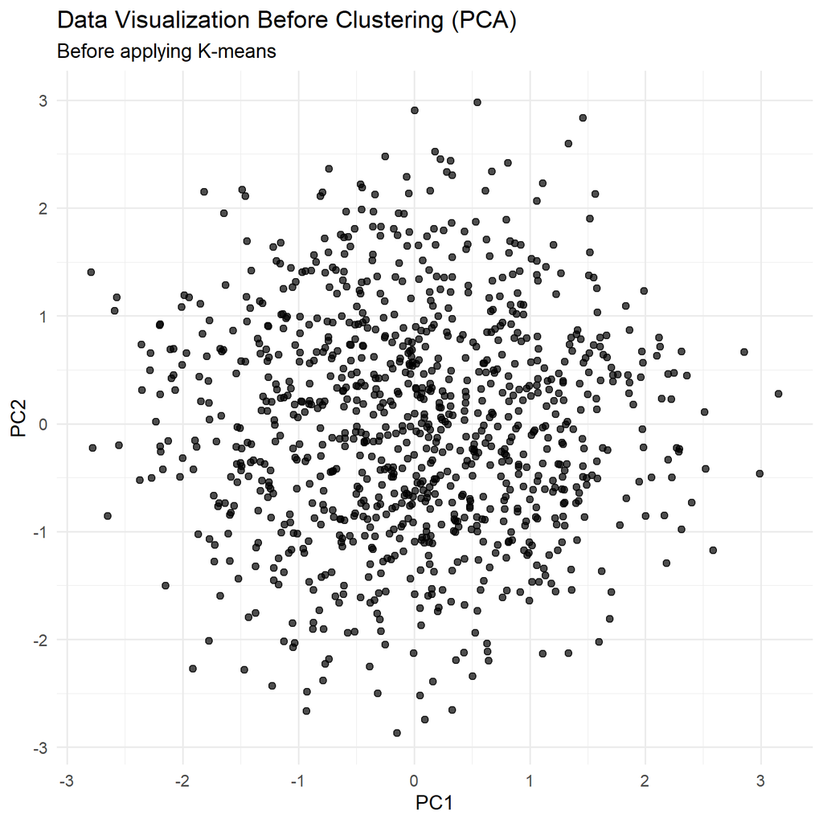

# Determining the appropriate number of clusters:

There are Two method for determining the appropriate number of clusters:

- Silhouette Coefficient Method: The Silhouette Coefficient Method is an internal validation technique used to evaluate clustering quality and select the optimal number of clusters. It measures how well each observation fits within its assigned cluster compared to other clusters, with values ranging from -1 to 1. Higher average silhouette values indicate better cluster separation, and the number of clusters that maximizes this average is typically considered optimal.

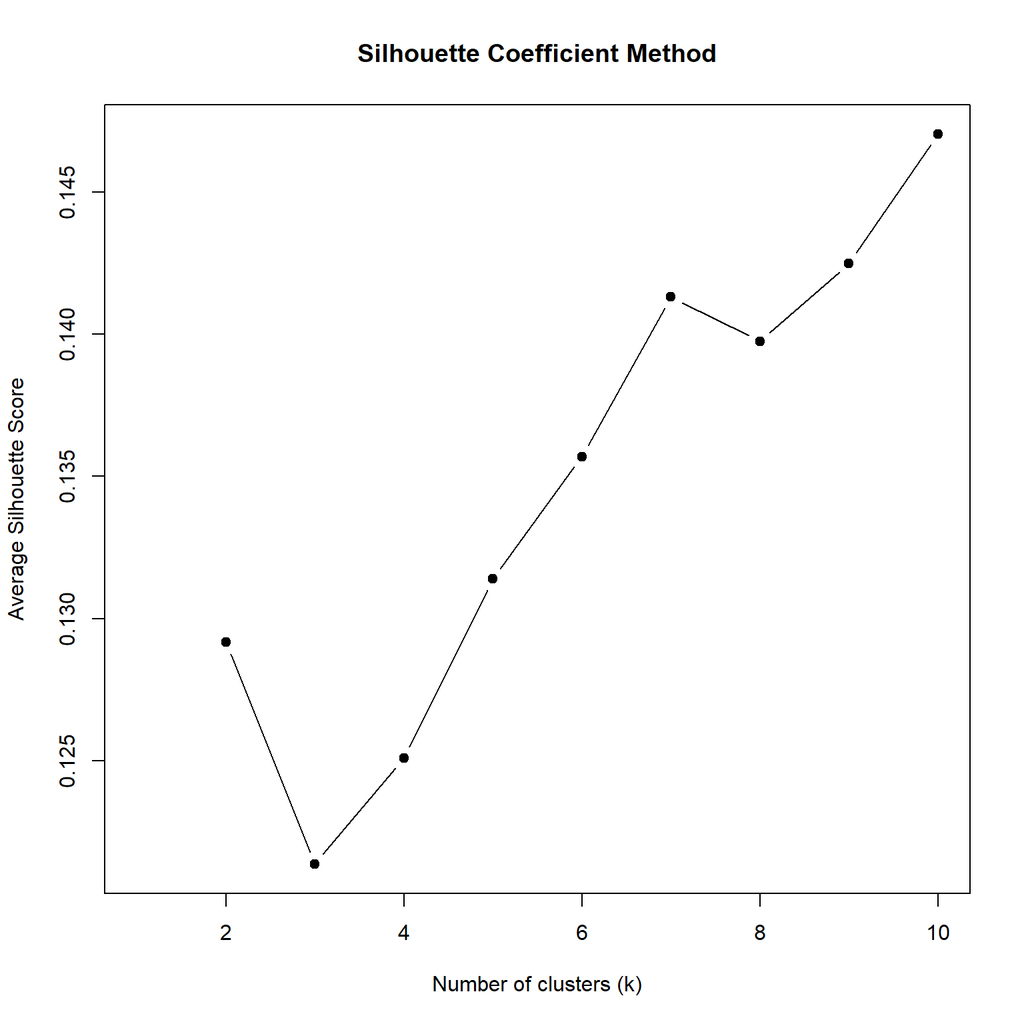

The Silhouette Coefficient analysis shows relatively low average silhouette values across all tested numbers of clusters, indicating weak separation among clusters. Although the highest silhouette score is observed at k = 10, the improvement over smaller values of k is marginal. Combined with the Elbow Method and PCA visualization, which suggest limited natural clustering structure, a five-cluster solution was selected to balance interpret ability and model simplicity

- Elbow Method: The Elbow Method is a heuristic technique used to determine the optimal number of clusters in K_means clustering. It is based on calculating the within_cluster sum of squares (WSS) for different numbers of clusters and plotting these values against the corresponding number of clusters. The optimal number of clusters is identified at the point where the decrease in WSS begins to slow down significantly, forming an “elbow” in the plot. This point represents a balance between minimizing within_cluster variance and avoiding unnecessary model complexity.

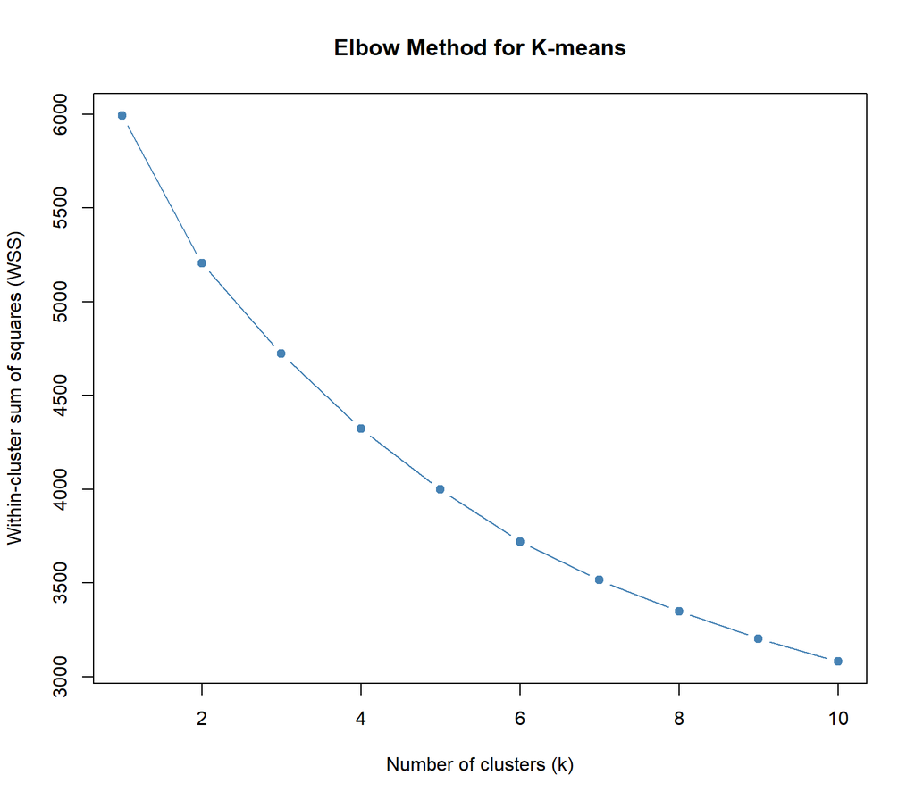

# Now Applying the Algorithm:

K-means Summary Results

| Metric | Value |
| --- | --- |
| Number of clusters (k) | 5 |
| Total within-cluster SS (tot.withinss) | 3996.766 |
| Between-cluster SS (betweenss) | 1997.234 |
| Total SS (totss) | 5994 |
| Explained variance (Between/Total) | 33.32% |

Cluster Sizes (Number of Observations per Cluster)

| Cluster | Count |
| --- | --- |
| 1 | 196 |
| 2 | 189 |
| 3 | 217 |
| 4 | 217 |
| 5 | 181 |

# Plot each cluster separately:

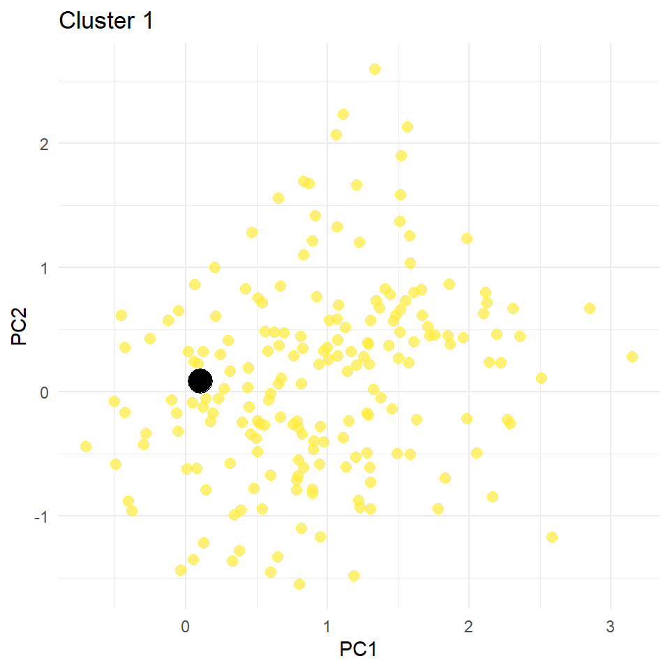

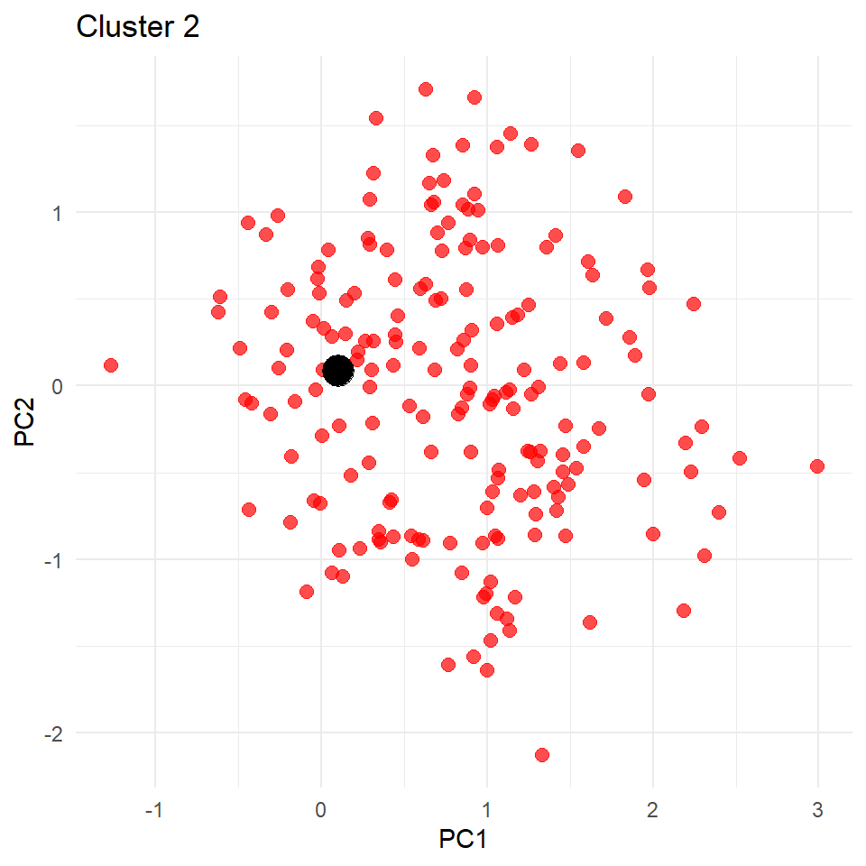

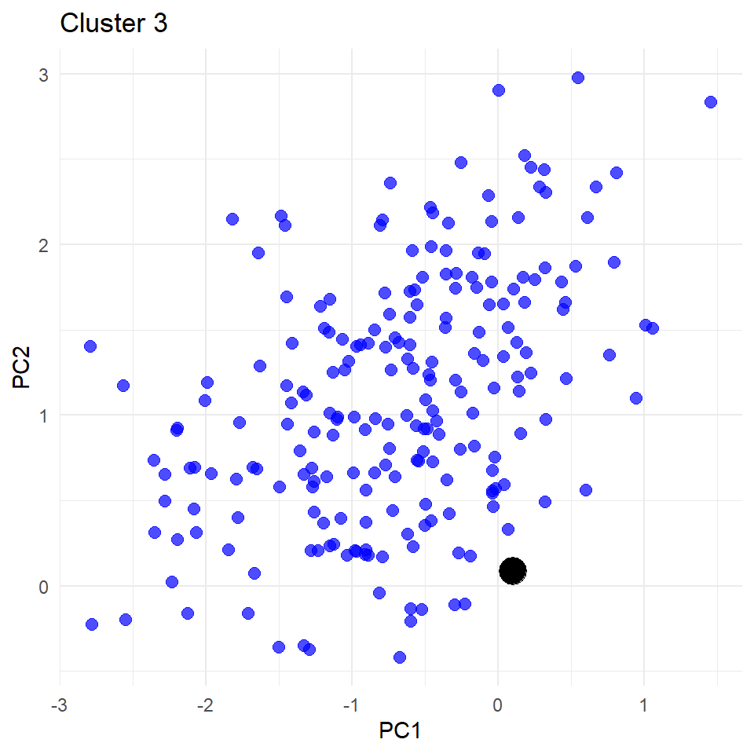

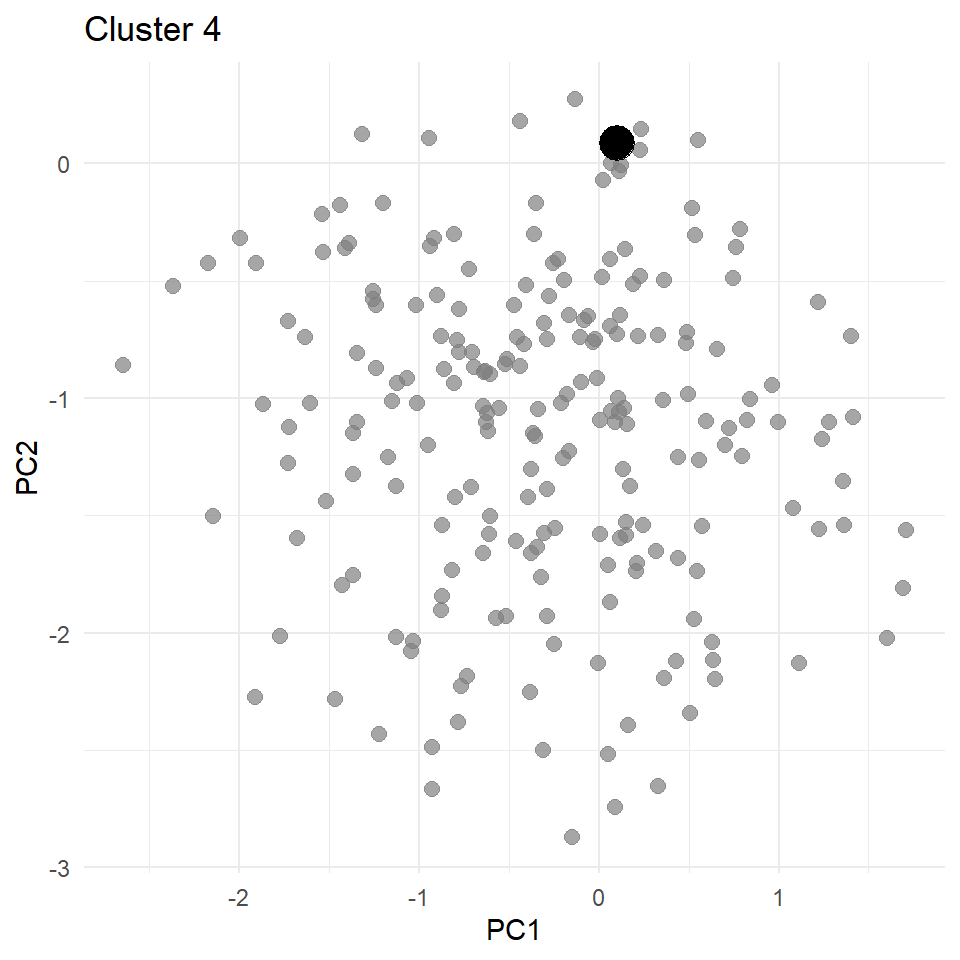

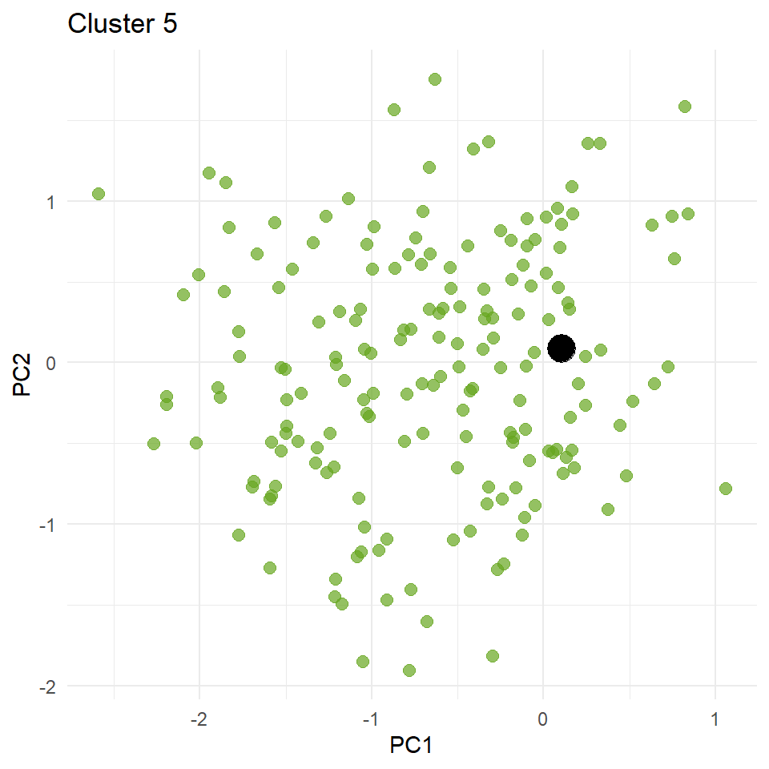

# Plot Final Results For Applting K_means Method:

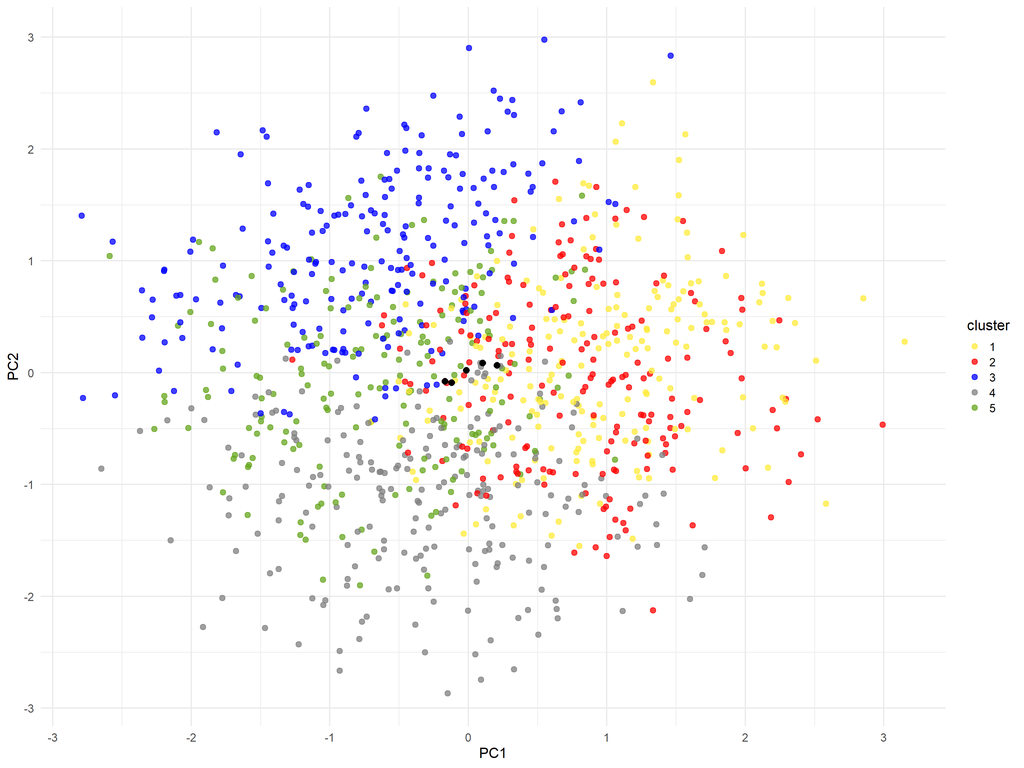

- Although K-means successfully partitioned the data into five clusters, the PCA visualization and low silhouette scores indicate substantial overlap among clusters. This suggests that the underlying data structure does not exhibit strong natural clustering, and the results should be interpreted with caution.